# Data Cleaning: Palmer Penguin Dataset

Aisha Mudasir

October 2025

# Introduction

The **Palmer Penguins dataset** contains physical measurements for three penguin species (*Adelie*, *Chinstrap*, and *Gentoo*) from the Palmer Archipelago, Antarctica.  
Before we can analyze relationships between their **flipper length** and **body mass**, it’s essential to clean and prepare the dataset.

This document describes each step of the cleaning process — including inspecting the data, handling missing values, checking data types, identifying outliers, and saving the cleaned dataset for analysis.

## 1) Load Required Packages and Dataset

Before we can clean data, we must load the libraries that contain the tools we’ll use and bring the dataset into our R environment.

```r
library(tidyverse)
library(palmerpenguins)
data("penguins")
head(penguins)
```

```
## # A tibble: 6 × 8
##   species island    bill_length_mm bill_depth_mm flipper_length_mm body_mass_g
##   <fct>   <fct>              <dbl>         <dbl>             <int>       <int>
## 1 Adelie  Torgersen           39.1          18.7               181        3750
## 2 Adelie  Torgersen           39.5          17.4               186        3800
## 3 Adelie  Torgersen           40.3          18                 195        3250
## 4 Adelie  Torgersen           NA            NA                  NA          NA
## 5 Adelie  Torgersen           36.7          19.3               193        3450
## 6 Adelie  Torgersen           39.3          20.6               190        3650
## # ℹ 2 more variables: sex <fct>, year <int>
```

- `tidyverse` provides functions like `filter()`, `mutate()`, and `summarise()`.
- `library(palmerpenguins)` loads the dataset.
- `head()` helps confirm successful loading.

#### Output

We should see a small preview of 6 rows showing columns like *species*, *island*, *bill_length_mm*, *flipper_length_mm*, *body_mass_g*, *sex*, and *year*.

## 2) Explore and Understand the Dataset

Understanding the dataset helps identify data types, missing values, and any inconsistencies before cleaning.

### 2.1 Check Structure and Summary

We will use `str()` function to show data types for each variable (e.g., numeric or factor) and `summary()` function to reveal min, max, median, mean, and NA counts.

```r
str(penguins)
```

```
## tibble [344 × 8] (S3: tbl_df/tbl/data.frame)
##  $ species          : Factor w/ 3 levels "Adelie","Chinstrap",..: 1 1 1 1 1 1 1 1 1 1 ...
##  $ island           : Factor w/ 3 levels "Biscoe","Dream",..: 3 3 3 3 3 3 3 3 3 3 ...
##  $ bill_length_mm   : num [1:344] 39.1 39.5 40.3 NA 36.7 39.3 38.9 39.2 34.1 42 ...
##  $ bill_depth_mm    : num [1:344] 18.7 17.4 18 NA 19.3 20.6 17.8 19.6 18.1 20.2 ...
##  $ flipper_length_mm: int [1:344] 181 186 195 NA 193 190 181 195 193 190 ...
##  $ body_mass_g      : int [1:344] 3750 3800 3250 NA 3450 3650 3625 4675 3475 4250 ...
##  $ sex              : Factor w/ 2 levels "female","male": 2 1 1 NA 1 2 1 2 NA NA ...
##  $ year             : int [1:344] 2007 2007 2007 2007 2007 2007 2007 2007 2007 2007 ...
```

```r
summary(penguins)
```

```
##       species          island    bill_length_mm  bill_depth_mm
##  Adelie   :152   Biscoe   :168   Min.   :32.10   Min.   :13.10
##  Chinstrap: 68   Dream    :124   1st Qu.:39.23   1st Qu.:15.60
##  Gentoo   :124   Torgersen: 52   Median :44.45   Median :17.30
##                                  Mean   :43.92   Mean   :17.15
##                                  3rd Qu.:48.50   3rd Qu.:18.70
##                                  Max.   :59.60   Max.   :21.50
##                                  NA's   :2       NA's   :2
##  flipper_length_mm  body_mass_g       sex           year
##  Min.   :172.0     Min.   :2700   female:165   Min.   :2007
##  1st Qu.:190.0     1st Qu.:3550   male  :168   1st Qu.:2007
##  Median :197.0     Median :4050   NA's  : 11   Median :2008
##  Mean   :200.9     Mean   :4202                Mean   :2008
##  3rd Qu.:213.0     3rd Qu.:4750                3rd Qu.:2009
##  Max.   :231.0     Max.   :6300                Max.   :2009
##  NA's   :2         NA's   :2
```

#### Output

The dataset consists of **344 rows** and **8 variables**, representing measurements of three penguin species. Most variables are numeric except for species, island, and sex, which are categorical. Flipper lengths range from **172–231 mm**, and body masses from **2700–6300 g**, with mean values of **~200.9 mm** and **~4202 g** respectively. A few missing values are present, especially in the sex column *(11 missing entries)*, indicating the need for data cleaning before analysis.

### 2.2 Check Column Names and Missing Values

Knowing where missing values are helps decide what needs to be cleaned or filtered out in the next step.

```r
colnames(penguins)
```

```
## [1] "species"           "island"            "bill_length_mm"
## [4] "bill_depth_mm"     "flipper_length_mm" "body_mass_g"
## [7] "sex"               "year"
```

```r
colSums(is.na(penguins))
```

```
##           species            island    bill_length_mm     bill_depth_mm
##                 0                 0                 2                 2
## flipper_length_mm       body_mass_g               sex              year
##                 2                 2                11                 0
```

#### Output

This output confirms that the dataset has eight well-defined columns.

- species, island, and year have **no** missing values.
- bill_length_mm, bill_depth_mm, flipper_length_mm, and body_mass_g — each contain **2** missing entries.
- The sex column has **11** missing values, which is the highest among all.

These will be addressed in the data cleaning phase to ensure reliable statistical and visual analysis.

## 3) Handle Missing Values

Missing data can cause errors or bias results in visualizations and analysis. We’ll remove rows missing **flipper length**, **body mass** and **sex** but retain others that don’t affect analysis. `filter(!is.na())` ensures all remaining rows have complete numeric data for reliable analysis.

```r
penguins_clean <- penguins %>%
  filter(!is.na(flipper_length_mm), !is.na(body_mass_g), !is.na(sex))
nrow(penguins_clean)
```

```
## [1] 333
```

```r
colSums(is.na(penguins_clean))
```

```
##           species            island    bill_length_mm     bill_depth_mm
##                 0                 0                 0                 0
## flipper_length_mm       body_mass_g               sex              year
##                 0                 0                 0                 0
```

#### Output

After filtering incomplete rows, the dataset now consists of **333** complete records. All missing values have been successfully removed, ensuring consistency and accuracy for further statistical and visualization steps.

## 4) Standardize and Format Data

To make sure R interprets columns correctly, categorical variables must be factors and numeric ones must be numeric.

### 4.1 Convert Data Types

This ensures that R treats species and other labels as categories for grouping and plotting later.

```r
penguins_clean <- penguins_clean %>%
  mutate(
    species = as.factor(species),
    island = as.factor(island),
    sex = as.factor(sex),
    year = as.integer(year)
  )
str(penguins_clean)
```

```
## tibble [333 × 8] (S3: tbl_df/tbl/data.frame)
##  $ species          : Factor w/ 3 levels "Adelie","Chinstrap",..: 1 1 1 1 1 1 1 1 1 1 ...
##  $ island           : Factor w/ 3 levels "Biscoe","Dream",..: 3 3 3 3 3 3 3 3 3 3 ...
##  $ bill_length_mm   : num [1:333] 39.1 39.5 40.3 36.7 39.3 38.9 39.2 41.1 38.6 34.6 ...
##  $ bill_depth_mm    : num [1:333] 18.7 17.4 18 19.3 20.6 17.8 19.6 17.6 21.2 21.1 ...
##  $ flipper_length_mm: int [1:333] 181 186 195 193 190 181 195 182 191 198 ...
##  $ body_mass_g      : int [1:333] 3750 3800 3250 3450 3650 3625 4675 3200 3800 4400 ...
##  $ sex              : Factor w/ 2 levels "female","male": 2 1 1 1 2 1 2 1 2 2 ...
##  $ year             : int [1:333] 2007 2007 2007 2007 2007 2007 2007 2007 2007 2007 ...
```

#### Output

Data types are appropriate — categorical variables are stored as factors, and measurements are numeric. This confirms that the dataset structure is now consistent and ready for further statistical analysis and visualization.

### 4.2 Check Unique Values in Each Column

This confirms categorical consistency (no duplicates like “Male” vs “male”).

```r
penguins_clean %>%
  summarise(
    species_types = n_distinct(species),
    islands = n_distinct(island),
    sexes = n_distinct(sex)
  )
```

```
## # A tibble: 1 × 3
##   species_types islands sexes
##           <int>   <int> <int>
## 1             3       3     2
```

#### Output

This output shows the count of **unique categories** within key categorical variables:

- **3 distinct species** (Adelie, Chinstrap, Gentoo)
- **3 islands** where observations were recorded (Biscoe, Dream, Torgersen)
- **2 sexes** (female, male)

This confirms that all categorical variables are consistent — there are no duplicate or misspelled category entries.

## 5) Detect and Handle Outliers

Outliers can distort averages or graphs. We’ll visualize and identify any extreme flipper or body mass values.

### 5.1 Visual Detection with Boxplots

The boxplots will show data distribution and any points outside whiskers (potential outliers). These visuals help us check if any penguin has unrealistic measurements.

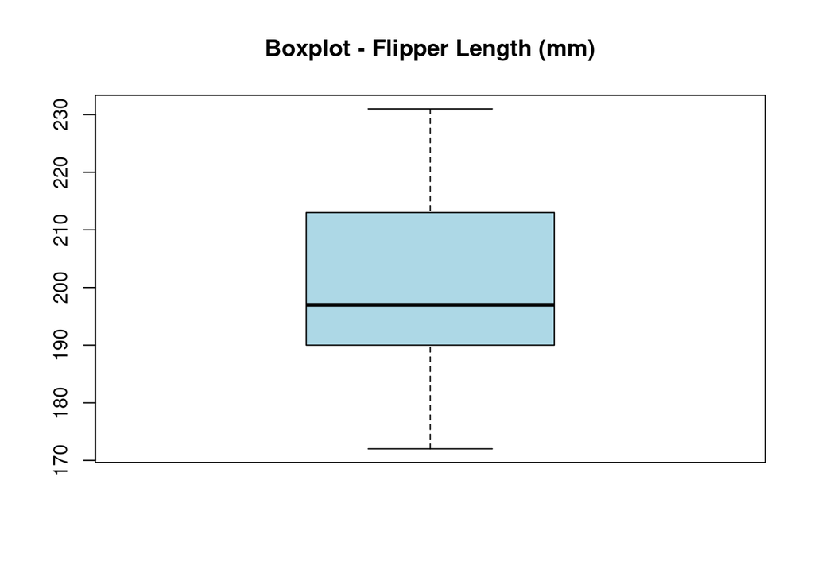

```r
boxplot(penguins_clean$flipper_length_mm,
        main = "Boxplot - Flipper Length (mm)",
        col = "lightblue")
```

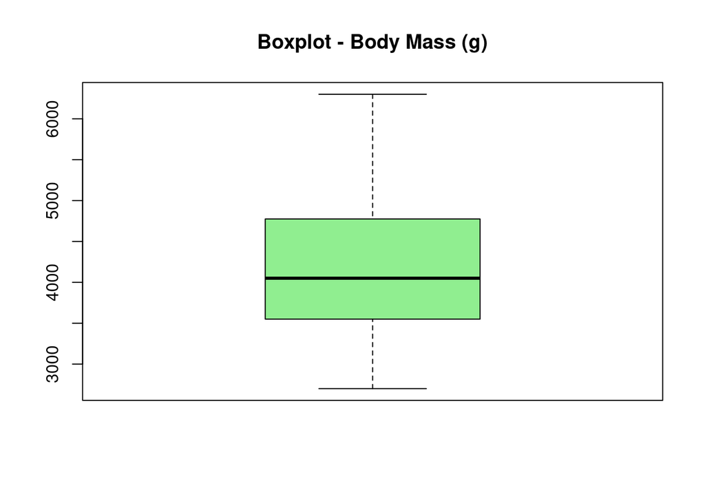

```r
boxplot(penguins_clean$body_mass_g,
        main = "Boxplot - Body Mass (g)",
        col = "lightgreen")
```

### 5.2 Identify Outliers Numerically

If the values seem biologically impossible (e.g., flipper <150 mm or >240 mm), we’ll remove them.

```r
flipper_outliers <- boxplot.stats(penguins_clean$flipper_length_mm)$out
bodymass_outliers <- boxplot.stats(penguins_clean$body_mass_g)$out

flipper_outliers
```

```
## integer(0)
```

```r
bodymass_outliers
```

```
## integer(0)
```

#### Output

No outliers were detected in flipper length or body mass measurements. This confirms that all recorded values are within biologically reasonable limits and can be safely retained for further statistical and visualization analysis.

### 5.3 Remove Unrealistic Outliers

Filtering keeps valid penguin records for more accurate analysis.

```r
penguins_clean <- penguins_clean %>%
  filter(body_mass_g > 2000 & body_mass_g < 7000)
```

Most of the dataset remains, only unrealistic weights (if any) are removed.

## Verify the Cleaned Dataset

We confirm that missing values, incorrect types, and outliers are handled correctly before saving.

```r
summary(penguins_clean)
```

```
##       species          island    bill_length_mm  bill_depth_mm
##  Adelie   :146   Biscoe   :163   Min.   :32.10   Min.   :13.10
##  Chinstrap: 68   Dream    :123   1st Qu.:39.50   1st Qu.:15.60
##  Gentoo   :119   Torgersen: 47   Median :44.50   Median :17.30
##                                  Mean   :43.99   Mean   :17.16
##                                  3rd Qu.:48.60   3rd Qu.:18.70
##                                  Max.   :59.60   Max.   :21.50
##  flipper_length_mm  body_mass_g       sex           year
##  Min.   :172       Min.   :2700   female:165   Min.   :2007
##  1st Qu.:190       1st Qu.:3550   male  :168   1st Qu.:2007
##  Median :197       Median :4050                Median :2008
##  Mean   :201       Mean   :4207                Mean   :2008
##  3rd Qu.:213       3rd Qu.:4775                3rd Qu.:2009
##  Max.   :231       Max.   :6300                Max.   :2009
```

```r
colSums(is.na(penguins_clean))
```

```
##           species            island    bill_length_mm     bill_depth_mm
##                 0                 0                 0                 0
## flipper_length_mm       body_mass_g               sex              year
##                 0                 0                 0                 0
```

```r
cat("Rows before cleaning:", nrow(penguins), "\n")
```

```
## Rows before cleaning: 344
```

```r
cat("Rows after cleaning:", nrow(penguins_clean), "\n")
```

```
## Rows after cleaning: 333
```

#### Output

The verification results confirm that the dataset is now fully cleaned, consistent, and complete. All numeric and categorical variables fall within realistic ranges, and there are no missing or invalid entries. The cleaned dataset contains 333 rows and 8 well-structured variables, ready for descriptive statistics and visualization in the analysis phase.

## 7) Save the Cleaned Dataset

We export the cleaned data for use in visualization and analysis notebooks.This ensures our cleaned dataset can be easily imported into future .Rmd files or Kaggle notebooks.

```r
if(!dir.exists("data/clean")) dir.create("data/clean", recursive = TRUE)
write_csv(penguins_clean, "data/clean/penguins_clean.csv")
list.files("data/clean")
```

```
## [1] "penguins_clean.csv"
```

#### Output

The console lists “penguins_clean.csv” inside your data/clean folder.